# Session 7 Practice: Importing, transforming and plotting data

Kenneth Tay

Oct 15, 2019

**Note: There are often multiple ways to answer each question.**

1. Download `nba_free_throws.csv` from https://github.com/kjytay/misc/tree/master/data. (Right click on `nba_free_throws.csv` and select “Save Link As…”). Import this dataset into R as the variable `df`. Are there columns which need their format changed? (You can read more about the dataset [here](https://www.kaggle.com/sebastianmantey/nba-free-throws/version/1).)

```r
# You can import it using the "Import Dataset" button as well.
# Code below only works if the csv file is in the current working directory.
# game_id should probably have character type
library(readr)
df <- read_csv("nba_free_throws.csv",
    col_types = cols(game_id = col_character()))
```

2. Select just the rows from the 2015-2016 regular season, remove the column `play` and save the result in `df2`.

```r
library(dplyr)
df2 <- df %>% filter(season == "2015 - 2016" & playoffs == "regular") %>%
    select(-play)
```

All questions from here are about `df2`.

3. Display the top 10 players who took the most free throws.

```r
df2 %>%
    group_by(player) %>%
    summarize(shots_taken = n()) %>%
    arrange(desc(shots_taken)) %>%
    head(n = 10)
```

```
## # A tibble: 10 x 2
##    player            shots_taken
##    <chr>                   <int>
##  1 James Harden              837
##  2 DeMarcus Cousins          663
##  3 DeMar DeRozan             653
##  4 DeAndre Jordan            619
##  5 Andre Drummond            586
##  6 Russell Westbrook         573
##  7 Andrew Wiggins            565
##  8 Isaiah Thomas             541
##  9 Paul George               528
## 10 Kevin Durant              498
```

4. Free throw percentage is defined as the percentage of shots taken which were made. Display the top 10 players with the highest free throw percentages. (Hint: modify Qn 3 code to take two summaries.)

```r
df2 %>%
    group_by(player) %>%
    summarize(shots_taken = n(), shots_made = sum(shot_made)) %>%
    mutate(free_throw_pct = shots_made / shots_taken * 100) %>%
    arrange(desc(free_throw_pct)) %>%
    head(n = 10)
```

```
## # A tibble: 10 x 4
##    player         shots_taken shots_made free_throw_pct
##    <chr>                <int>      <dbl>          <dbl>
##  1 Branden Dawson           1          1            100
##  2 Chris Kaman              3          3            100
##  3 Chuck Hayes              2          2            100
##  4 Damjan Rudez             8          8            100
##  5 Erick Green              2          2            100
##  6 Jarell Eddie             8          8            100
##  7 Jeff Ayres               6          6            100
##  8 Jodie Meeks              4          4            100
##  9 Jordan Farmar           10         10            100
## 10 Keith Appling            2          2            100
```

5. The highest free throw percentages are so high because these players didn’t take many shots. Display the top 10 players with the highest free throw percentages **among only the players who took at least 100 free throws**. (Hint: Filter Qn 4 code at an appropriate step.)

```r
df2 %>%
    group_by(player) %>%
    summarize(shots_taken = n(), shots_made = sum(shot_made)) %>%
    filter(shots_taken >= 100) %>%
    mutate(free_throw_pct = shots_made / shots_taken * 100) %>%
    arrange(desc(free_throw_pct)) %>%
    head(n = 10)
```

```
## # A tibble: 10 x 4
##    player         shots_taken shots_made free_throw_pct
##    <chr>                <int>      <dbl>          <dbl>
##  1 Stephen Curry          400        363           90.8
##  2 Jamal Crawford         271        245           90.4
##  3 Kevin Durant           498        447           89.8
##  4 Chris Paul             328        294           89.6
##  5 Dirk Nowitzki          280        250           89.3
##  6 Jarrett Jack           112        100           89.3
##  7 Damian Lillard         464        414           89.2
##  8 Kevin Martin           172        153           89.0
##  9 Kyrie Irving           188        167           88.8
## 10 Eric Gordon            125        111           88.8
```

6. Save the summary table of shots taken, shots made and free throw percentage by player in `summary_df` (only players who took at least 100 free throws). Using `summary_df`, make a scatterplot of free throw percentage vs. free throws taken. Set the `alpha` value of the points to `0.5`, and draw a blue dashed horizontal line to show the mean free throw percentage across these players. (Hint: For the horizontal line, use `geom_abline`.)

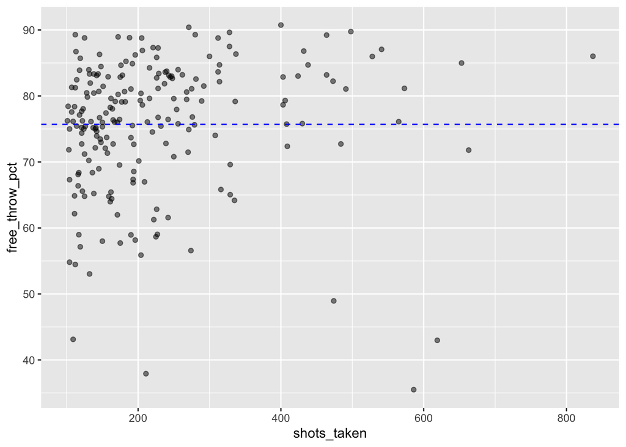

```r
library(ggplot2)
summary_df <- df2 %>%
    group_by(player) %>%
    summarize(shots_taken = n(), shots_made = sum(shot_made)) %>%
    filter(shots_taken >= 100) %>%
    mutate(free_throw_pct = shots_made / shots_taken * 100)
ggplot(summary_df, aes(x = shots_taken, y = free_throw_pct)) +
    geom_point(alpha = 0.5) +
    geom_abline(slope = 0, intercept = mean(summary_df$free_throw_pct),
                linetype = "dashed", col = "blue")
```

7. Which game (in `df2`) had the most number of free throws? Save the rows in `df2` from that game in `df3`.

```r
# This can be done more easily by visually inspecting the game_id with most free
# throws, then hardcoding it into the filter. The solution below does this
# programmatically.
id <- pull(df2 %>% group_by(game_id) %>%
    summarize(game = unique(game), shots_taken = n()) %>%
    arrange(desc(shots_taken)), game_id)[1]

df3 <- df2 %>% filter(game_id == id)
```

8. Make a bar plot showing the number of free throws each player took in this game. Add `coord_flip()` as a layer to the plot so that the bars are horizontal. Sort the bars such that the longest ones go on top. (Hint: The `forcats` package will be helpful here, as will the last example of Section 15.4 of R4DS.)

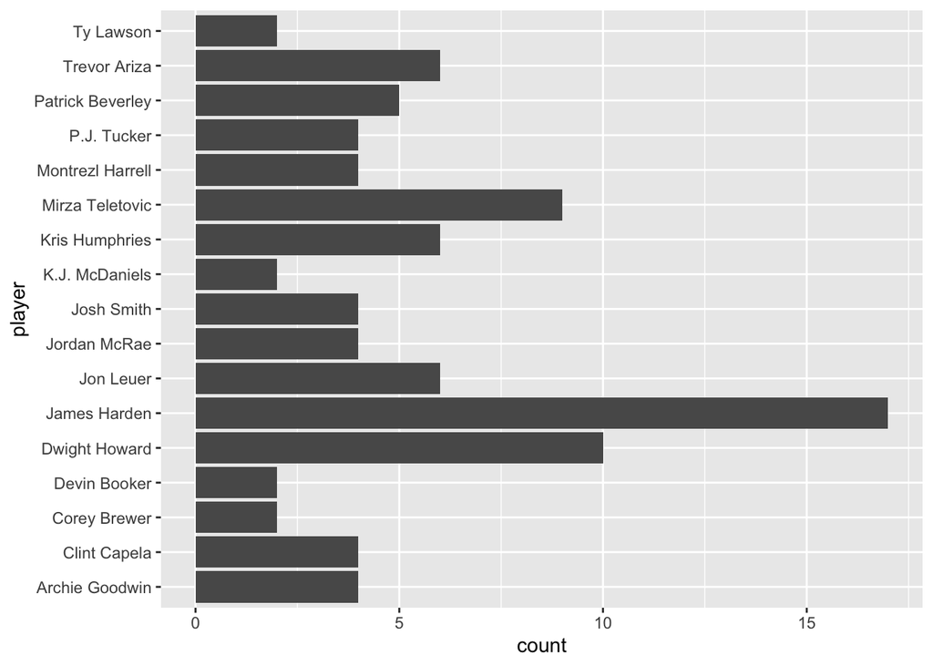

```r
# without sorting of bars
ggplot(df3, aes(x = player)) +
    geom_bar() +
    coord_flip()
```

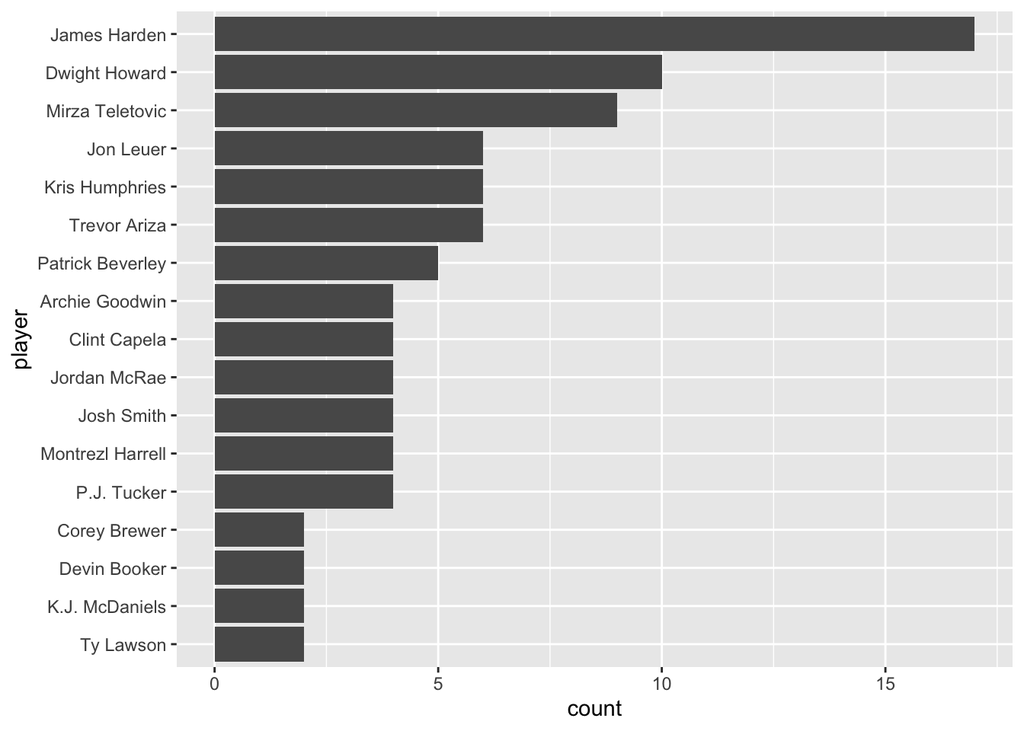

```r
# with sorting of bars
library(forcats)
df3 %>% mutate(player = player %>% fct_infreq() %>% fct_rev()) %>%
    ggplot(aes(x = player)) +
    geom_bar() +
    coord_flip()
```

The following code joins data from `summary_df` to `df3` and saves it as df4 (treat it as a magical incantation for now: the `left_join()` function is from the `dplyr` package):

```r
df4 <- df3 %>% left_join(summary_df, by = "player")
```

9. Modify your bar plot in Qn 8 so that the fill of the bars is equal to the player’s free throw percentage. Add the layer `scale_fill_distiller(palette = "RdYlGn", direction = 1)` to give your bars some appropriate colors. Why are some bars grey?

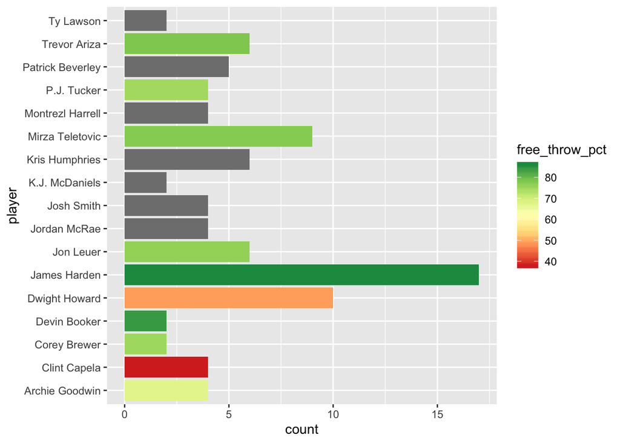

```r
# summary_df only contains data for players who attempted at least 100 shots.
# For players with less than 100 shots, the new columns added by the left_join
# are all set to NA.
ggplot(df4, aes(x = player)) +
    geom_bar(aes(fill = free_throw_pct)) +
    scale_fill_distiller(palette = "RdYlGn", direction = 1) +
    coord_flip()
```

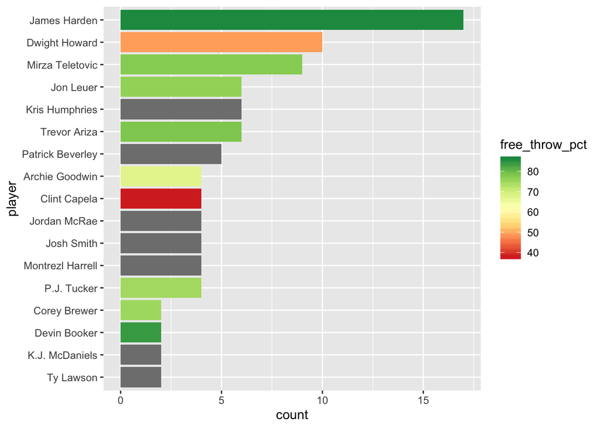

```r
# with sorting of bars
df4 %>% mutate(player = player %>% fct_infreq() %>% fct_rev()) %>%
    ggplot(aes(x = player)) +
    geom_bar(aes(fill = free_throw_pct)) +
    scale_fill_distiller(palette = "RdYlGn", direction = 1) +
    coord_flip()
```

10. Using `tidyr`’s `separate` function, separate the `game` column in `df2` to a `home` column which has the name of the home team, and an `away` column which has the name of the away team.

```r
library(tidyr)
df2 %>%
    separate(game, into = c("home", "away"))
```

```
## # A tibble: 57,304 x 11
##    end_result home  away  game_id period player playoffs score season
##    <chr>      <chr> <chr> <chr>    <dbl> <chr>  <chr>    <chr> <chr>
##  1 106 - 94   DET   ATL   400827…      1 Marcu… regular  5 - 4 2015 …
##  2 106 - 94   DET   ATL   400827…      1 Marcu… regular  5 - 4 2015 …
##  3 106 - 94   DET   ATL   400827…      1 Andre… regular  10 -… 2015 …
##  4 106 - 94   DET   ATL   400827…      1 Andre… regular  10 -… 2015 …
##  5 106 - 94   DET   ATL   400827…      1 Paul … regular  15 -… 2015 …
##  6 106 - 94   DET   ATL   400827…      1 Paul … regular  15 -… 2015 …
##  7 106 - 94   DET   ATL   400827…      1 Reggi… regular  23 -… 2015 …
##  8 106 - 94   DET   ATL   400827…      2 Al Ho… regular  31 -… 2015 …
##  9 106 - 94   DET   ATL   400827…      2 Al Ho… regular  31 -… 2015 …
## 10 106 - 94   DET   ATL   400827…      3 Kenta… regular  56 -… 2015 …
## # … with 57,294 more rows, and 2 more variables: shot_made <dbl>,
## #   time <time>
```